# Modern Contraceptive Use in Nigeria

An Analysis of Demographic and Health Survey Data 2018

Marco Cattaneo

`25-12-17`

# 1 Introduction

Nigeria faces a substantial unmet need for family planning, and ongoing maternal and child health challenges, making the study of modern contraceptive use a public health priority. Improving access to and uptake of modern contraceptive methods is essential for reducing unintended pregnancies, lowering maternal mortality, and supporting women’s health, autonomy, and socioeconomic development. The objective of this analysis is to assess the prevalence of modern contraceptive use among women of reproductive age in Nigeria and to identify the socioeconomic and geographic factors associated with its adoption.

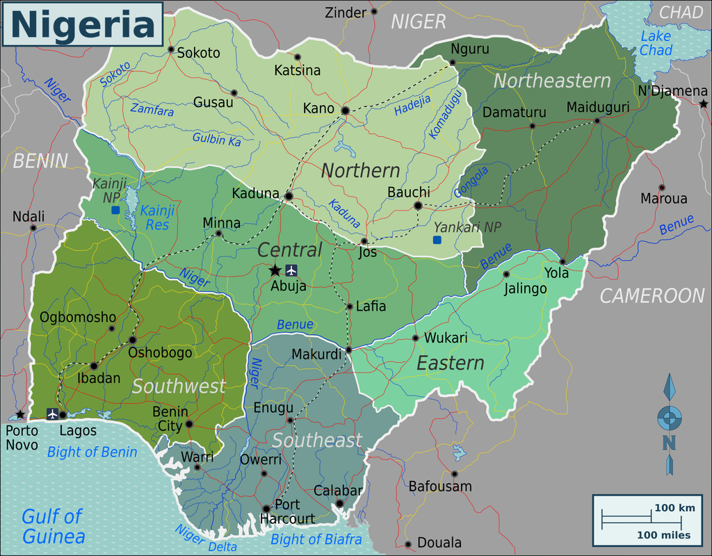

In particular, this analysis examines contraceptive use patterns among Nigerian women of reproductive age (15–49 years) using data from the 2018 Nigeria Demographic and Health Survey (NDHS). The study includes a nationally representative sample of 41,821 women across Nigeria’s six geopolitical regions, with a mean respondent age of 29 years. It explores the prevalence of modern contraceptive methods and identifies key demographic, socioeconomic, and geographic factors associated with contraceptive adoption. The full characteristics of the study sample are presented in *Appendix 1*.

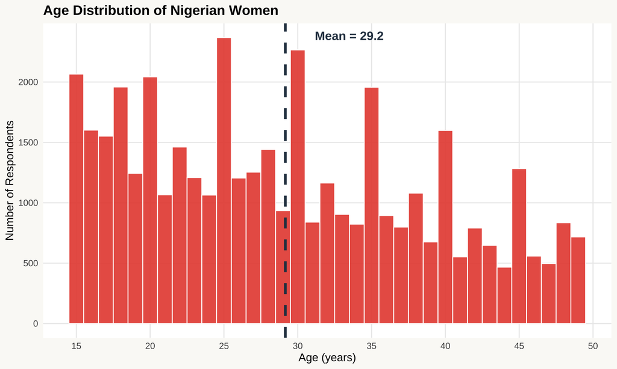

# 2 Overall Contraceptive Prevalence

The data reveal that contraceptive use remains relatively low in Nigeria, with the majority of women (86.5%) not using any form of contraception. Among contraceptive users, modern methods dominate, accounting for approximately 75.8% of all contraceptive use, while traditional and folkloric methods represent smaller proportions. This pattern suggests that when Nigerian women choose to use contraception, they predominantly opt for evidence-based modern methods such as injectables, implants, and oral contraceptives.

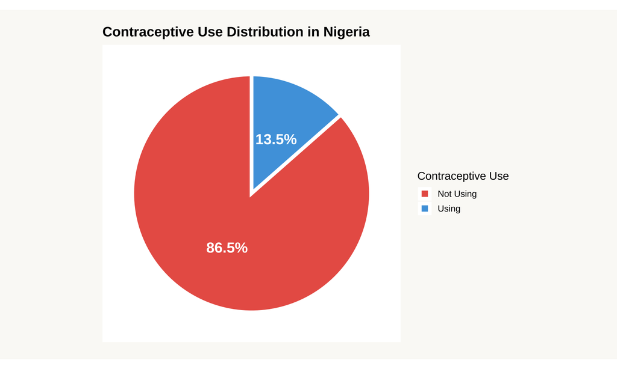

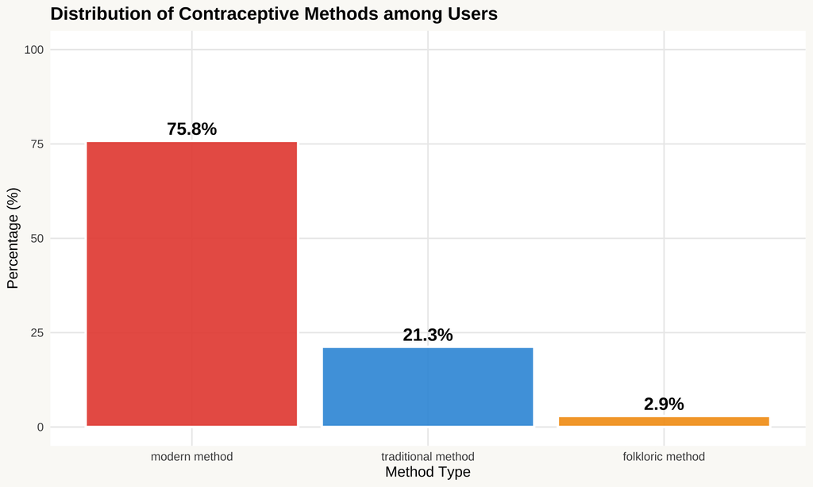

# 3 Determinants of Modern Contraceptive Use in Nigeria

To better understand patterns of modern contraceptive use in Nigeria, the following sections examine differences by geographic region, religious affiliation, and socioeconomic status, highlighting how these dimensions contribute to unequal levels of contraceptive adoption across the country.

## 3.1 Geographic Disparities

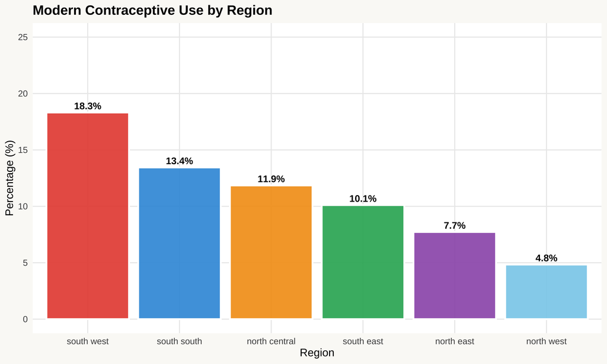

## 3.2 Religious Affiliation as a Determinant of Modern Contraceptive Use

Religious affiliation is associated with contraceptive use patterns, with Christian women (both Catholic and other Christian denominations) showing higher prevalence rates than Muslim women. However, these religious differences likely intersect with regional patterns, as Christianity predominates in southern Nigeria while Islam is more prevalent in the north.

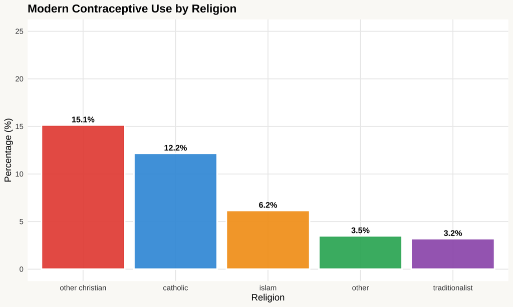

## 3.3 Socioeconomic Gradients

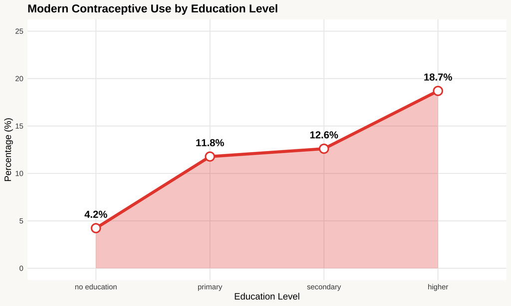

Wealth-based disparities are equally pronounced. The slope chart comparing the poorest and richest quintiles across regions demonstrates that economic status influences contraceptive use across all geographic areas. The wealth gap, represented by the steepness of the connecting lines, varies by region, with some areas showing more dramatic socioeconomic inequalities than others. Notably, even within the poorest wealth quintile, South-West and South-South regions maintain higher prevalence than northern regions, suggesting that regional cultural factors operate independently of economic status.

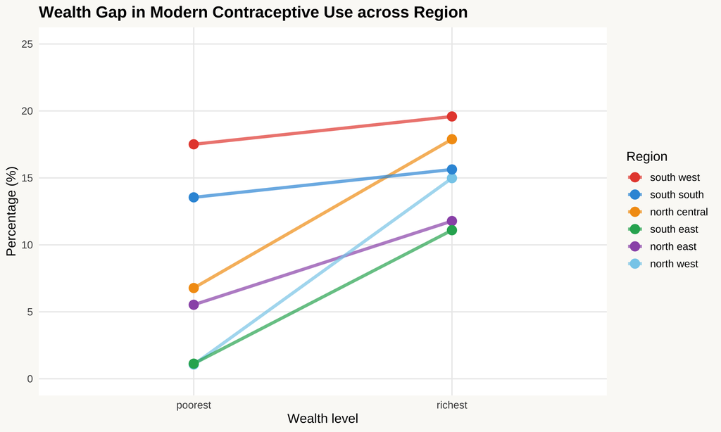

# 4 Implications

These findings highlight the multidimensional nature of contraceptive access and use in Nigeria. Geographic, educational, and economic barriers operate simultaneously, creating complex patterns of disparity. Effective family planning programs must address these multiple dimensions through region-specific interventions, educational investments, and efforts to reduce economic barriers to contraceptive access. The predominance of modern methods among users suggests that supply-side factors and method availability may be less critical than demand-side factors such as education, cultural norms, and economic empowerment in explaining overall low contraceptive prevalence.

# 5 Limitations

The analysis did not account for statistical weights, and a comprehensive statistical evaluation was not performed. Consequently, the findings are specific to the sample of respondents, may have limited generalizability, and the conclusions should be interpreted with caution.

# 6 *Appendix 1*

**Table 1. Sample Characteristics**

| **Characteristic** | **N = 41,821**<sup>1</sup> |
| --- | --- |
| Age (years) | 29.2 (9.7) |
| Total Children | 3.0 (3.0) |
| Age at First Birth | 19.7 (4.5) |
| Region |  |
| north central | 7,772 (19%) |
| north east | 7,639 (18%) |
| north west | 10,129 (24%) |
| south east | 5,571 (13%) |
| south south | 5,080 (12%) |
| south west | 5,630 (13%) |
| Residence Type |  |
| urban | 16,984 (41%) |
| rural | 24,837 (59%) |
| Education Level |  |
| no education | 14,398 (34%) |
| primary | 6,383 (15%) |
| secondary | 16,698 (40%) |
| higher | 4,342 (10%) |
| Religion |  |
| catholic | 4,436 (11%) |
| other christian | 16,070 (38%) |
| islam | 20,959 (50%) |
| traditionalist | 156 (0.4%) |
| other | 200 (0.5%) |
| Wealth Index |  |
| poorest | 7,747 (19%) |
| poorer | 8,346 (20%) |
| middle | 8,859 (21%) |
| richer | 8,840 (21%) |
| richest | 8,029 (19%) |
| Marital Status |  |
| never in union | 10,669 (26%) |
| married | 27,841 (67%) |
| living with partner | 1,047 (2.5%) |
| widowed | 1,117 (2.7%) |
| divorced | 543 (1.3%) |
| no longer living together/separated | 604 (1.4%) |

<sup>1</sup> Mean (SD); n (%)